# Programists Poll

Penza Street Analitics

23 11 2019

# Опрос программистов от PenzaStreetAnalitics

## Данные

```r
poll <- read.csv("article_data.csv", encoding = "UTF-8")
poll["X"] <- NULL
head(poll)
```

```
##      gender languages_number back_front_end
## 1 Кафельный                2        Бек-энд
## 2   Мужской                1        Бек-энд
## 3   Мужской                1        Бек-энд
## 4   Мужской                3       Фул-стек
## 5   Мужской                2       Фул-стек
## 6   Мужской                6        Бек-энд
```

Группой **PenzaStreetAnalitics** была собрана информация об 111 программистах следующего содержания:

1. Пол испытуемого (*gender*)
   - Примечание: в данных имеются записи с “кафельным полом”. Это означает, что программист не счёл важным уточнять свой пол. Для большего охвата, будем учитывать и эту группу.
2. Количество языков программирования (*languages_number*)
3. А также, какую отрасль web-разработки он бы предпочёл: серверную (*бэк-энд*), клиентскую (*фронт-энд*) или всё сразу (*фул-стек*) (*back_front_end*)

## Гипотеза

> Влияет ли пол программиста на его выбор отрасли web’а? А также влияет ли выбор отрасли сетевой разработки на количество языков программирования, которые знает программист?

## Исследование

В исследовании использовался язык **R** версии 3.6.1 Также используется библиотека ggplot2

```r
library(ggplot2)
```

### Зависимость пола и отрасли web’а

Для проверки гипотезы используем точный тест Фишера:

```r
hyp_1 <- fisher.test(table(poll$gender, poll$back_front_end))
hyp_1
```

```
##
##  Fisher's Exact Test for Count Data
##
## data:  table(poll$gender, poll$back_front_end)
## p-value = 0.00486
## alternative hypothesis: two.sided
```

p-уровень значимости меньше 0.05 (0.0048598), значит, есть хотя бы одно значимое различие. Визуализируем взаимосвязь:

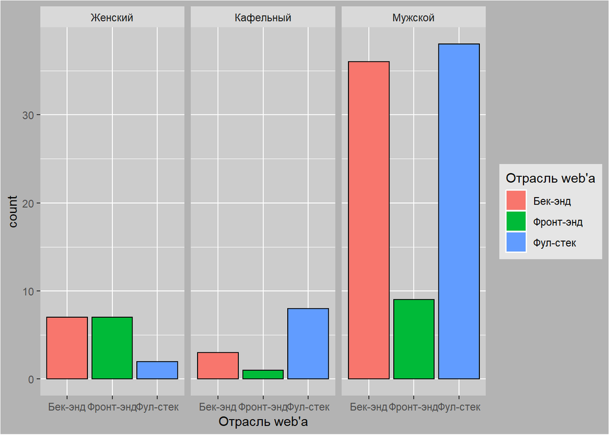

Зависимость пола и отрасли web’а

```r
ggplot(poll, aes(back_front_end, fill = back_front_end, color = I("black")))+
  geom_histogram(stat = "count")+
  facet_wrap(~gender)+
  scale_fill_discrete(name = "Отрасль web'а")+
  xlab("Отрасль web'а")+
  theme(panel.background = element_rect(fill = "grey80"),
          plot.background = element_rect(fill = "grey70"),
        legend.background = element_rect(fill = "grey90"))
```

Можно сделать следующие выводы:

1. Частота встречаемости бек-энда и фул-стека у мужчин примерно равна, но фронт-энд встречается реже.
2. Люди с кафельным полом, больше специализирутся на фул-стек разработке.
3. Женщины выбирают фронт-энд чаще, чем остальные. Однако, с такой же частотой он выбирают бек-энд, но редко выбирают фул-стек.

### Зависимость отрасли web’а и количества языков программирования

Проверим нормальность распредения количества языков, с помощью теста Шапиро-Вилка:

```r
norm_hyp <- shapiro.test(poll$languages_number)
norm_hyp
```

```
##
##  Shapiro-Wilk normality test
##
## data:  poll$languages_number
## W = 0.87702, p-value = 4.021e-08
```

p-уровень значимости меньше 0.05 (4.02145610^{-8}), значит, распределение отличается от нормального. Для проверки гипотезы используем тест Краскела-Уоллеса:

```r
hyp_2 <- kruskal.test(poll$languages_number, poll$back_front_end)
hyp_2
```

```
##
##  Kruskal-Wallis rank sum test
##
## data:  poll$languages_number and poll$back_front_end
## Kruskal-Wallis chi-squared = 6.0245, df = 2, p-value = 0.04918
```

p-уровень значимости меньше 0.05 (0.0491798), значит, есть хотя бы одно значимое различие.

Визуализируем взаимосвязь:

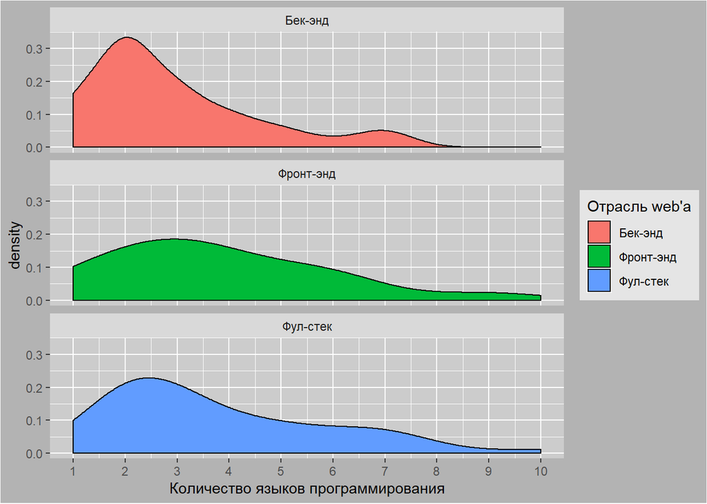

Зависимость отрасли web’а и количества языков программирования

```r
ggplot(poll, aes(languages_number, fill = back_front_end, color = I("black")))+
  geom_density()+
  facet_wrap(~back_front_end, nrow = 3)+
  scale_x_continuous(name = "Количество языков программирования",
                     breaks = c(1:10))+
  scale_fill_discrete(name = "Отрасль web'а")+
  theme(panel.background = element_rect(fill = "grey80"),
        plot.background = element_rect(fill = "grey70"),
        legend.background = element_rect(fill = "grey90"))
```

Можно сделать следующие выводы:

1. У всех трёх отраслей наибольшее число программистов знают 2-3 языка.
2. Для фронт-энда прослеживается большая частота встречаемости программистов, знающих >7 языков по сравнению с бек-эндом. Такое же различие заметно для фул-стека.

## Вывод

Программисты - странные люди. Как оказалось, в их обществе тоже существуют свои закономерности и правила. Их исследованию можно уделить множество статей. Но как-нибудь в другой раз.